# Bicycle Renting Dataset in Kaggle

Context Bike sharing systems are a new generation of traditional bike rentals where the whole process from membership, rental and return back has become automatic. Through these systems, user is able to easily rent a bike from a particular position and return back to another position. Currently, there are about over 500 bike-sharing programs around the world which are composed of over 500 thousands bicycles. Today, there exists great interest in these systems due to their important role in traffic, environmental and health issues.

Apart from interesting real-world applications of bike sharing systems, the characteristics of data being generated by these systems make them attractive for the research. Opposed to other transport services such as bus or subway, the duration of travel, departure and arrival position is explicitly recorded in these systems. This feature turns bike sharing system into a virtual sensor network that can be used for sensing mobility in the city. Hence, it is expected that most of important events in the city could be detected via monitoring these data.

This dataset contains the hourly and daily count of rental bikes between years 2011 and 2012 in Capital bikeshare system in Washington, DC with the corresponding weather and seasonal information.

Content Both hour.csv and day.csv have the following fields, except hr which is not available in day.csv

instant: Record index dteday: Date season: Season (1:springer, 2:summer, 3:fall, 4:winter) yr: Year (0: 2011, 1:2012) mnth: Month (1 to 12) hr: Hour (0 to 23) holiday: weather day is holiday or not (extracted from Holiday Schedule) weekday: Day of the week workingday: If day is neither weekend nor holiday is 1, otherwise is 0. weathersit: (extracted from Freemeteo) 1: Clear, Few clouds, Partly cloudy, Partly cloudy 2: Mist + Cloudy, Mist + Broken clouds, Mist + Few clouds, Mist 3: Light Snow, Light Rain + Thunderstorm + Scattered clouds, Light Rain + Scattered clouds 4: Heavy Rain + Ice Pallets + Thunderstorm + Mist, Snow + Fog temp: Normalized temperature in Celsius. The values are derived via (t-t_min)/(t_max-t_min), t_min=-8, t_max=+39 (only in hourly scale) atemp: Normalized feeling temperature in Celsius. The values are derived via (t-t_min)/(t_max-t_min), t_min=-16, t_max=+50 (only in hourly scale) hum: Normalized humidity. The values are divided to 100 (max) windspeed: Normalized wind speed. The values are divided to 67 (max) casual: count of casual users registered: count of registered users cnt: count of total rental bikes including both casual and registered

```r
library(gdata)
df = read.csv("day.csv")
df
```

```
##     instant     dteday season yr mnth holiday weekday workingday
## 1         1 2011-01-01      1  0    1       0       6          0
## 2         2 2011-01-02      1  0    1       0       0          0
## 3         3 2011-01-03      1  0    1       0       1          1
## 4         4 2011-01-04      1  0    1       0       2          1
## 5         5 2011-01-05      1  0    1       0       3          1
## 6         6 2011-01-06      1  0    1       0       4          1
## 7         7 2011-01-07      1  0    1       0       5          1
## 8         8 2011-01-08      1  0    1       0       6          0
## 9         9 2011-01-09      1  0    1       0       0          0
## 10       10 2011-01-10      1  0    1       0       1          1
## 11       11 2011-01-11      1  0    1       0       2          1
## 12       12 2011-01-12      1  0    1       0       3          1
## 13       13 2011-01-13      1  0    1       0       4          1
## 14       14 2011-01-14      1  0    1       0       5          1
```

[output cut: 2181 more lines]

# Scatter plot of temperature, humidity and windspeed

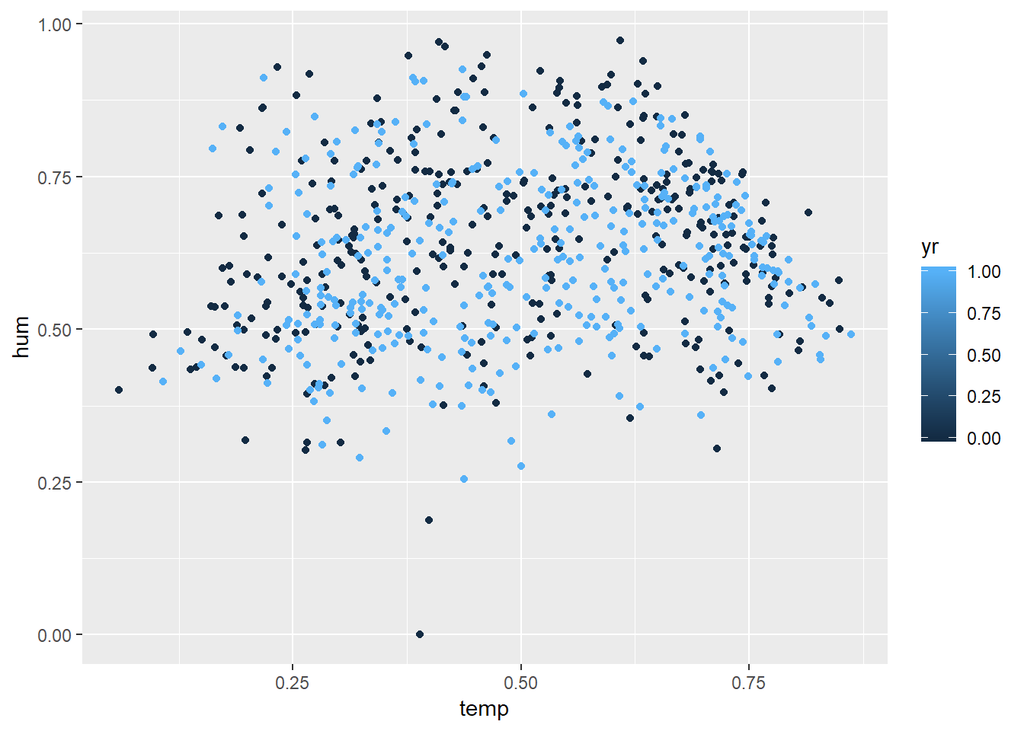

```r
library(ggplot2)
my.scatter_1 = ggplot(df, aes(temp, hum, color = yr))
my.scatter_1 = my.scatter_1 + layer( geom = "point",
                                   stat = "identity",
                                   position = "identity",
                                   params = list(na.rm = FALSE))
my.scatter_1
```

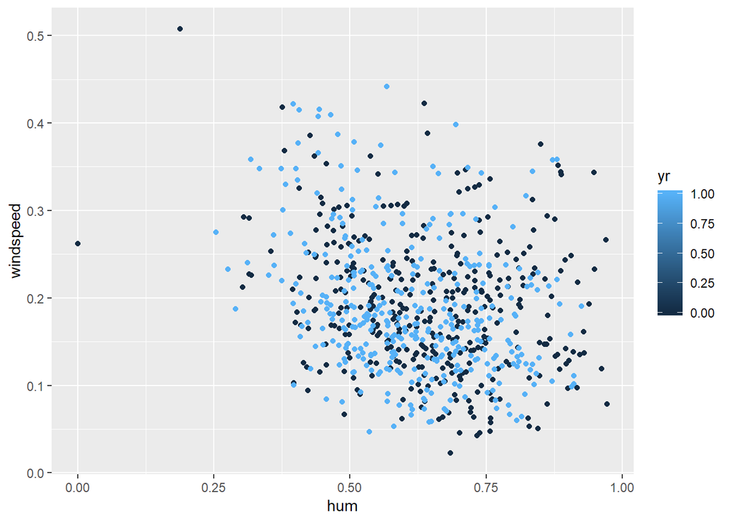

```r
my.scatter_2 = ggplot(df, aes(hum, windspeed, color = yr))
my.scatter_2 = my.scatter_2 + layer( geom = "point",
                                   stat = "identity",
                                   position = "identity",
                                   params = list(na.rm = FALSE))
my.scatter_2
```

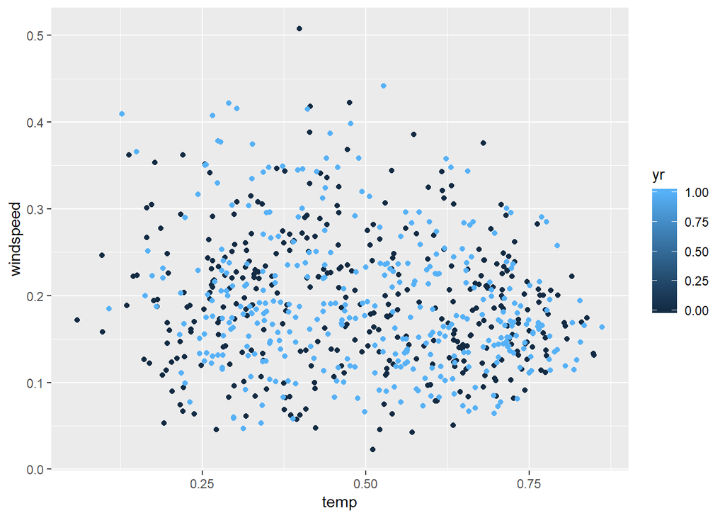

```r
my.scatter_3 = ggplot(df, aes(temp, windspeed, color = yr))
my.scatter_3 = my.scatter_3 + layer( geom = "point",
                                   stat = "identity",
                                   position = "identity",
                                   params = list(na.rm = FALSE))
my.scatter_3
```

# different Users renting the bikes on different years

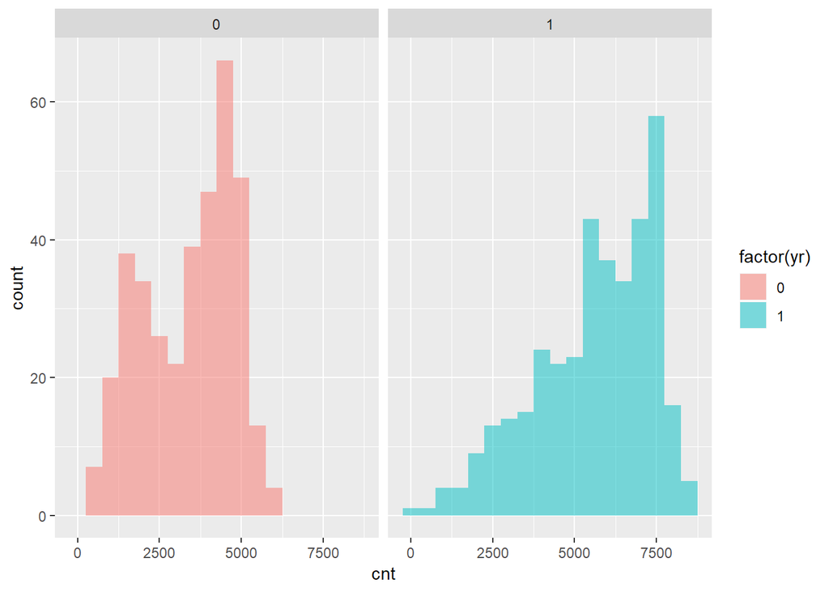

```r
my.bar_plot_1 = ggplot(df, aes(x = cnt, fill = factor(yr)))
my.bar_plot_1 = my.bar_plot_1 + layer(
  geom = "bar",
  stat = "bin",
  position = "identity",
  params = list(
    binwidth = 500,
    na.rm = FALSE,
    alpha = 0.5)
    ) + facet_wrap(~factor(yr))
my.bar_plot_1
```

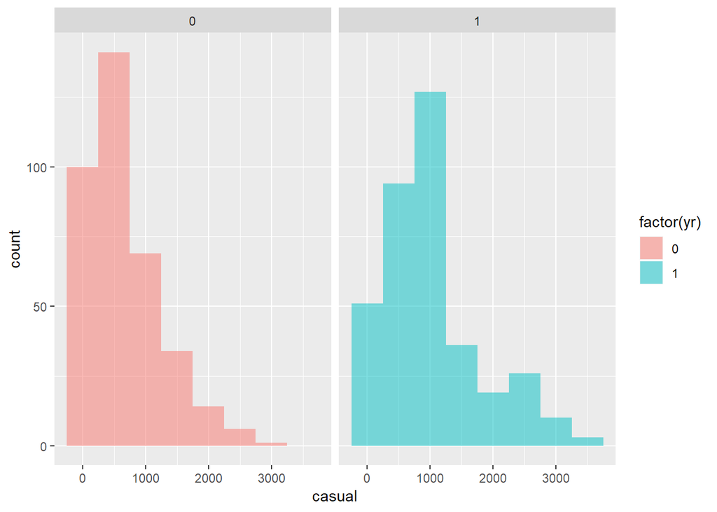

```r
my.bar_plot_2 = ggplot(df, aes(x = casual, fill = factor(yr)))
my.bar_plot_2 = my.bar_plot_2 + layer(
  geom = "bar",
  stat = "bin",
  position = "identity",
  params = list(
    binwidth = 500,
    na.rm = FALSE,
    alpha = 0.5)
    ) + facet_wrap(~factor(yr))
my.bar_plot_2
```

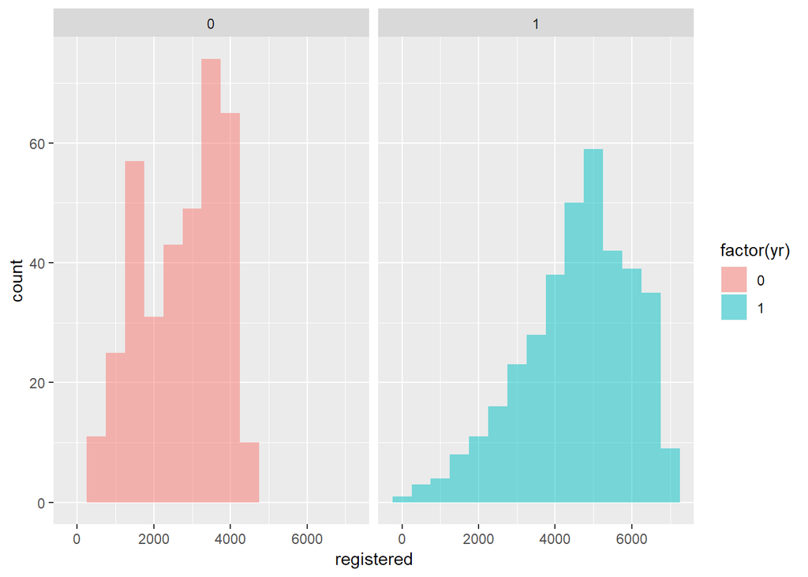

```r
my.bar_plot_3 = ggplot(df, aes(x = registered, fill = factor(yr)))
my.bar_plot_3 = my.bar_plot_3 + layer(
  geom = "bar",
  stat = "bin",
  position = "identity",
  params = list(
    binwidth = 500,
    na.rm = FALSE,
    alpha = 0.5)
    ) + facet_wrap(~factor(yr))
my.bar_plot_3
```

# Visualize the effect of different time to the renting count

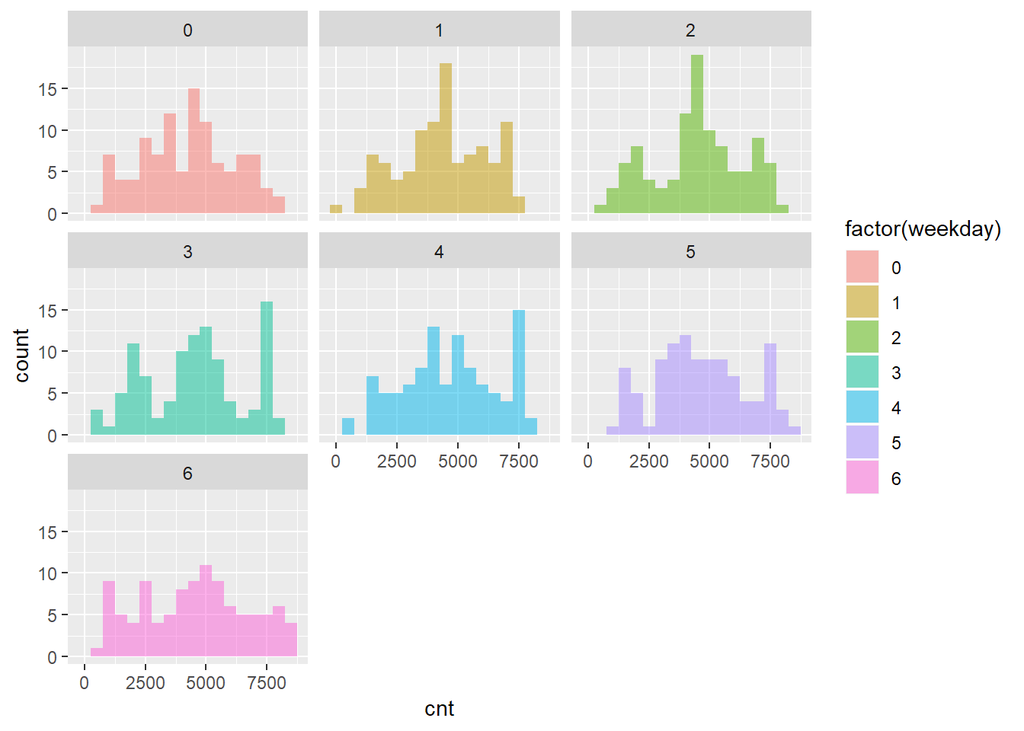

```r
my.week_day_plot = ggplot(df, aes(x = cnt, fill = factor(weekday)))
my.week_day_plot = my.week_day_plot + layer(
  geom = "bar",
  stat = "bin",
  position = "identity",
  params = list(
    binwidth = 500,
    na.rm = FALSE,
    alpha = 0.5)
    ) + facet_wrap(~factor(weekday))
my.week_day_plot
```

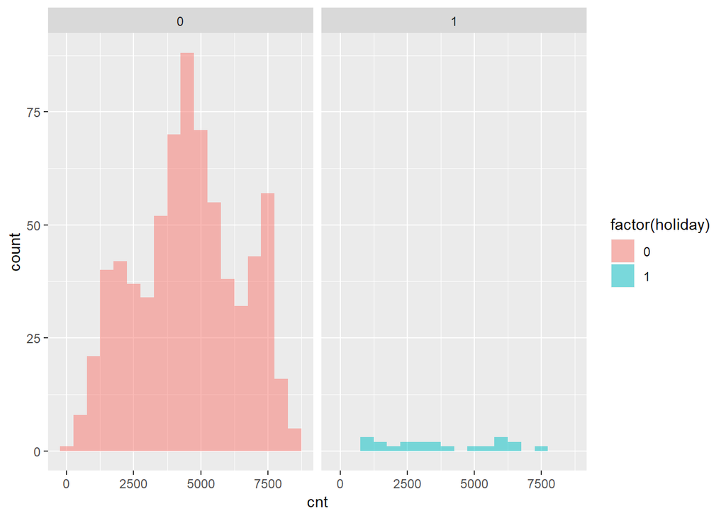

```r
my.holiday_plot = ggplot(df, aes(x = cnt, fill = factor(holiday)))
my.holiday_plot = my.holiday_plot + layer(
  geom = "bar",
  stat = "bin",
  position = "identity",
  params = list(
    binwidth = 500,
    na.rm = FALSE,
    alpha = 0.5)
    ) + facet_wrap(~factor(holiday))
my.holiday_plot
```

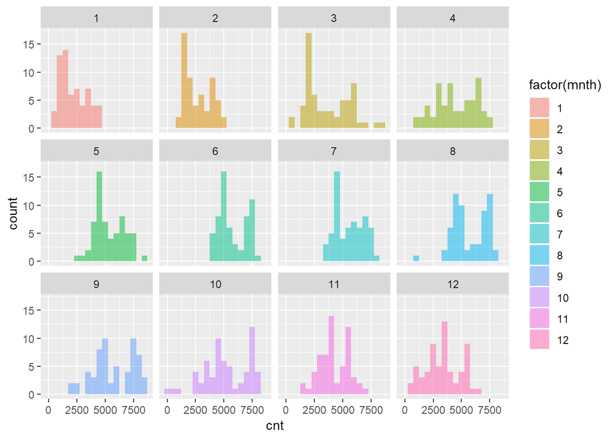

```r
my.month_plot = ggplot(df, aes(x = cnt, fill = factor(mnth)))
my.month_plot = my.month_plot + layer(
  geom = "bar",
  stat = "bin",
  position = "identity",
  params = list(
    binwidth = 500,
    na.rm = FALSE,
    alpha = 0.5)
    ) + facet_wrap(~factor(mnth))
my.month_plot
```